# 1 Exercise: Research Workflow with mtcars Dataset

## 1.1 Objective 1: Load the mtcars dataset

Students will load the `mtcars` dataset from the `datasets` package.

**Required Functions:** - `data()`

**Solution Code 1:**

```r
data("mtcars")
head(mtcars)
```

|  | mpg | cyl | disp | hp | drat | wt | qsec | vs | am | gear | carb |
| --- | --- | --- | --- | --- | --- | --- | --- | --- | --- | --- | --- |
| Mazda RX4 | 21.0 | 6 | 160 | 110 | 3.90 | 2.620 | 16.46 | 0 | 1 | 4 | 4 |
| Mazda RX4 Wag | 21.0 | 6 | 160 | 110 | 3.90 | 2.875 | 17.02 | 0 | 1 | 4 | 4 |
| Datsun 710 | 22.8 | 4 | 108 | 93 | 3.85 | 2.320 | 18.61 | 1 | 1 | 4 | 1 |
| Hornet 4 Drive | 21.4 | 6 | 258 | 110 | 3.08 | 3.215 | 19.44 | 1 | 0 | 3 | 1 |
| Hornet Sportabout | 18.7 | 8 | 360 | 175 | 3.15 | 3.440 | 17.02 | 0 | 0 | 3 | 2 |
| Valiant | 18.1 | 6 | 225 | 105 | 2.76 | 3.460 | 20.22 | 1 | 0 | 3 | 1 |

## 1.2 Objective 2: Data Transformation/Reshaping

**2.1:** Add a new column to the dataset called “efficiency” which is computed as miles per gallon (`mpg`) divided by horsepower (`hp`).

**2.2:** Filter the dataset to only retain rows where the number of cylinders (`cyl`) is 4.

**Required Functions:** - `mutate()` from the `dplyr` package for creating the new variable. - `filter()` from the `dplyr` package for filtering the data.

**Solution Code 2:**

```r
library(dplyr)

# 2.1
mtcars <- mtcars %>%
  mutate(efficiency = mpg/hp)

# 2.2
filtered_mtcars <- mtcars %>%
  filter(cyl == 4)

head(filtered_mtcars)
```

|  | mpg | cyl | disp | hp | drat | wt | qsec | vs | am | gear | carb | efficiency |
| --- | --- | --- | --- | --- | --- | --- | --- | --- | --- | --- | --- | --- |
| Datsun 710 | 22.8 | 4 | 108.0 | 93 | 3.85 | 2.320 | 18.61 | 1 | 1 | 4 | 1 | 0.2451613 |
| Merc 240D | 24.4 | 4 | 146.7 | 62 | 3.69 | 3.190 | 20.00 | 1 | 0 | 4 | 2 | 0.3935484 |
| Merc 230 | 22.8 | 4 | 140.8 | 95 | 3.92 | 3.150 | 22.90 | 1 | 0 | 4 | 2 | 0.2400000 |
| Fiat 128 | 32.4 | 4 | 78.7 | 66 | 4.08 | 2.200 | 19.47 | 1 | 1 | 4 | 1 | 0.4909091 |
| Honda Civic | 30.4 | 4 | 75.7 | 52 | 4.93 | 1.615 | 18.52 | 1 | 1 | 4 | 2 | 0.5846154 |
| Toyota Corolla | 33.9 | 4 | 71.1 | 65 | 4.22 | 1.835 | 19.90 | 1 | 1 | 4 | 1 | 0.5215385 |

## 1.3 Objective 3: Data Visualization

**3.1:** Create a scatter plot of horsepower (`hp`) on the x-axis and miles per gallon (`mpg`) on the y-axis, where each point represents a car. Color the points by the number of cylinders (`cyl`).

**3.2:** On the same plot, facet by the transmission type (`am`, where 0 = automatic and 1 = manual).

**Required Functions:** - `ggplot()`, `aes()`, `geom_point()`, and `facet_wrap()` from the `ggplot2` package. jv **Solution Code 3:**

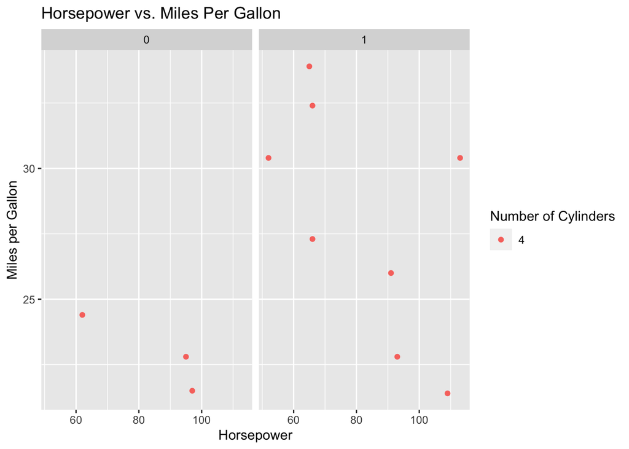

```r
library(ggplot2)

# 3.1 & 3.2
plot <- ggplot(filtered_mtcars, aes(x=hp, y=mpg, color=factor(cyl))) +
  geom_point() +
  facet_wrap(~am) +
  labs(title="Horsepower vs. Miles Per Gallon",
       x="Horsepower",
       y="Miles per Gallon",
       color="Number of Cylinders")

print(plot)
```

# 2 Exercise: Research Workflow with flights Dataset

## 2.1 Objective 1: Load the flights dataset

Load the `flights` dataset from the `nycflights13` package.

**Required Functions:** - `library()`

**Solution Code 1:**

```r
library(nycflights13)
data("flights")
head(flights)
```

| year | month | day | dep_time | sched_dep_time | dep_delay | arr_time | sched_arr_time | arr_delay | carrier | flight | tailnum | origin | dest | air_time | distance | hour | minute | time_hour |
| --- | --- | --- | --- | --- | --- | --- | --- | --- | --- | --- | --- | --- | --- | --- | --- | --- | --- | --- |
| 2013 | 1 | 1 | 517 | 515 | 2 | 830 | 819 | 11 | UA | 1545 | N14228 | EWR | IAH | 227 | 1400 | 5 | 15 | 2013-01-01 05:00:00 |
| 2013 | 1 | 1 | 533 | 529 | 4 | 850 | 830 | 20 | UA | 1714 | N24211 | LGA | IAH | 227 | 1416 | 5 | 29 | 2013-01-01 05:00:00 |
| 2013 | 1 | 1 | 542 | 540 | 2 | 923 | 850 | 33 | AA | 1141 | N619AA | JFK | MIA | 160 | 1089 | 5 | 40 | 2013-01-01 05:00:00 |
| 2013 | 1 | 1 | 544 | 545 | -1 | 1004 | 1022 | -18 | B6 | 725 | N804JB | JFK | BQN | 183 | 1576 | 5 | 45 | 2013-01-01 05:00:00 |
| 2013 | 1 | 1 | 554 | 600 | -6 | 812 | 837 | -25 | DL | 461 | N668DN | LGA | ATL | 116 | 762 | 6 | 0 | 2013-01-01 06:00:00 |
| 2013 | 1 | 1 | 554 | 558 | -4 | 740 | 728 | 12 | UA | 1696 | N39463 | EWR | ORD | 150 | 719 | 5 | 58 | 2013-01-01 05:00:00 |

## 2.2 Objective 2: Data Transformation/Reshaping

**2.1:** Filter the dataset to only retain rows where the `month` is January.

**2.2:** Compute the average arrival delay (`arr_delay`) for each `carrier`.

**Required Functions:** - `filter()` and `group_by()` + `summarise()` from the `dplyr` package.

**Solution Code 2:**

```r
library(dplyr)

# 2.1
january_flights <- flights %>%
  filter(month == 1)

# 2.2
carrier_avg_delay <- january_flights %>%
  group_by(carrier) %>%
  summarise(avg_arr_delay = mean(arr_delay, na.rm = TRUE))

print(carrier_avg_delay)
```

```
## # A tibble: 16 × 2
##    carrier avg_arr_delay
##    <chr>           <dbl>
##  1 9E             10.2
##  2 AA              0.982
##  3 AS              8.97
##  4 B6              4.72
##  5 DL             -4.40
##  6 EV             25.2
##  7 F9             21.8
##  8 FL              3.32
##  9 HA             27.5
## 10 MQ              7.88
## 11 OO            107
## 12 UA              3.18
## 13 US              1.43
## 14 VX            -15.3
## 15 WN              5.89
## 16 YV             13.8
```

## 2.3 Objective 3: Data Visualization

Create a bar plot of different carriers on the x-axis and their corresponding average arrival delay on the y-axis.

**Required Functions:** - `ggplot()`, `aes()`, `geom_bar()`, and `labs()` from the `ggplot2` package.

**Solution Code 3:**

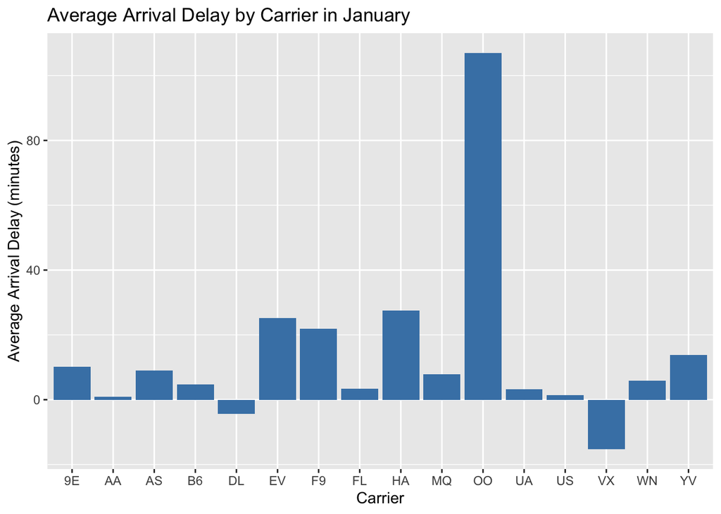

```r
library(ggplot2)

plot <- ggplot(carrier_avg_delay, aes(x = carrier, y = avg_arr_delay)) +
  geom_bar(stat = "identity", fill = "steelblue") +
  labs(title = "Average Arrival Delay by Carrier in January",
       x = "Carrier",
       y = "Average Arrival Delay (minutes)")

print(plot)
```

## 2.4 Objective 4: Regression Analysis

Run a basic regression analysis to determine the relationship between distance (`distance`) and arrival delay (`arr_delay`), controlling for `air_time`.

**Required Functions:** - `feols()` from the `fixest` package.

**Solution Code 4:**

```r
library(fixest)

# Remove NA values for regression analysis
january_flights_clean <- january_flights %>%
  filter(!is.na(arr_delay) & !is.na(distance) & !is.na(air_time))

# Run regression
regression_result <- feols(arr_delay ~ distance + air_time, data = january_flights_clean)

print(regression_result)
```

```
## OLS estimation, Dep. Var.: arr_delay
## Observations: 26,398
## Standard-errors: IID
##              Estimate Std. Error   t value
## (Intercept) -4.275665   0.567432  -7.53511
## distance    -0.096364   0.002338 -41.22333
## air_time     0.700928   0.017717  39.56134
##               Pr(>|t|)
## (Intercept) 5.0355e-14 ***
## distance     < 2.2e-16 ***
## air_time     < 2.2e-16 ***
## ---
## Signif. codes:  0 '***' 0.001 '**' 0.01 '*' 0.05 '.' 0.1 ' ' 1
## RMSE: 39.1   Adj. R2: 0.062934
```